# Probabilistic Modelling

Eadan Fahey

16 March 2017

## Motivating Example

Can we predict the outcome of a tennis match?

| tourney_name | tourney_date | player_name | opponent_name | outcome |
| --- | --- | --- | --- | --- |
| Orlando | 2000-05-01 | Antony Dupuis | Andrew Ilie | 1 |
| Orlando | 2000-05-01 | Fernando Gonzalez | Cecil Mamiit | 1 |
| Orlando | 2000-05-01 | Paradorn Srichaphan | Sebastien Lareau | 1 |
| Orlando | 2000-05-01 | Jan Siemerink | Justin Gimelstob | 1 |
| Orlando | 2000-05-01 | Jason Stoltenberg | Alex Lopez Moron | 1 |

53,000 matches & 2,100 players.

## What is Probabilistic Modelling?

**Model**

A story we tell ourselves about how the world works.

**Probability**

A way of quantifying our uncertainty about the world.

## Probability Distributions

Expressing belief

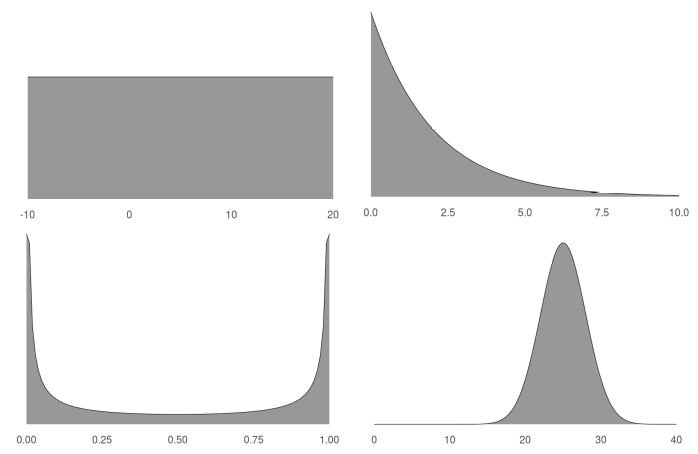

## Modelling Player Skill

Assumptions:

- Each player has a “**skill**” level ($\mu$).
- The skill level across the entire population of players is normally distributed.
- The “**performance**” of a player in any match is normally distributed around their skill level.
- The standard deviation ($\sigma$) of the performance distribution measures how **consistent** the player is.
- The player with the higher performance wins the match.

## Generative Process

Psuedocode

```
N = number of players
M = number of matches

for each player n = 1, ..., N:
    mu[n] ~ Normal(mean = 1000, sd = 300)  // skill level

sigma ~ Gamma(mean = 100, sd = 30)  // performance consistency

for each match m = 1, ..., M:
    performance_a ~ Normal(mean = mu[a], sd = sigma)
    performance_b ~ Normal(mean = mu[b], sd = sigma)

    if performance_a > performance_b:
        player A wins
    else:
        player B wins
```

## Two player example (part 1)

Generate skills and consistency

```r
num_players <- 2
num_matches <- 10000
mu <- rnorm(num_players, mean = 1000, sd = 300)
sigma <- rgamma(1, shape = 10, rate = 0.1)

print(mu)
```

```
## [1] 1220.730 1028.768
```

```r
print(sigma)
```

```
## [1] 110.2691
```

## Two player example (part 2)

Generate Performances

```r
performance_p1 <- rnorm(num_matches, mean = mu[1], sd = sigma)
performance_p2 <- rnorm(num_matches, mean = mu[2], sd = sigma)
```

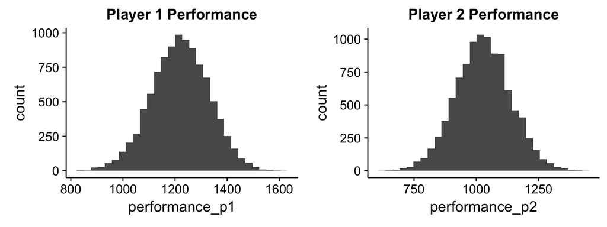

## Two player example (part 3)

Probability of winning

```r
performance_diff <- performance_p1 - performance_p2
prob_p1_wins <- sum(performance_diff > 0) / length(performance_diff)
print(prob_p1_wins)
```

```
## [1] 0.8852
```

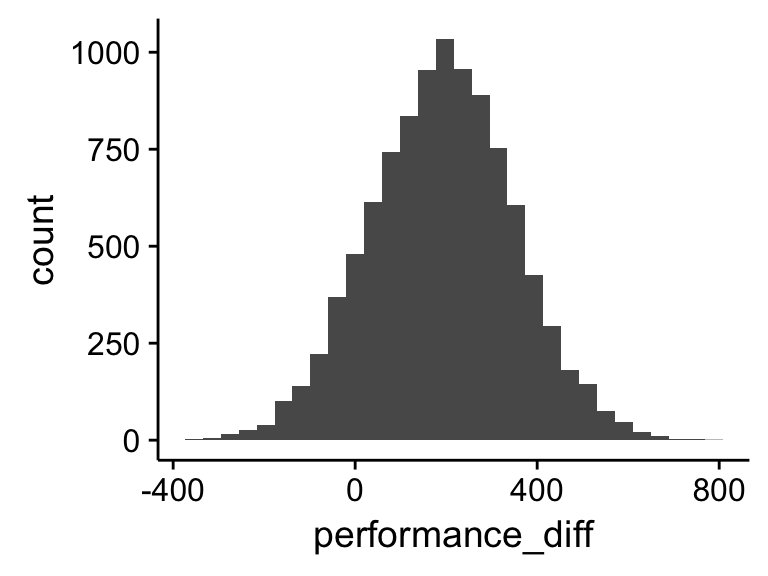

## Reversing the process

Generate data:

Parameters —> Data

Inference:

Data —> Parameters

How do we do inference?

## Core Principle

Bayes’ Rule

$$P\left(\theta \mid Data\right) = \frac{P(Data \mid \theta) P(\theta)}{P(Data)}$$

**Very** computationally expensive (exponential in the number of parameters)

Sampling methods: MCMC

## Tools for Inference

- BUGS
- JAGS
- PyMC3 (Python)
- Edward (Python)
- Figaro (Scala)
- Infer.Net (C# / F#)
- Church (~ Scheme)
- Venturescript
- Stan (R / Python / Julia / Matlab / CLI)

## Expressing our model in Stan

model.stan

```
data {
    int<lower=0> N;    // number of players
    int<lower=0> M;    // number of matches
    int winner_id[M];  // winner of each match
    int loser_id[M];   // loser of each match
    int outcome[M];    // outcome of each match (just a list of ones)
}
parameters {
    vector[N] skill;
    real<lower=0> consistency;
}
model {
    skill ~ normal(1000, 300);
    consistency ~ gamma(10, 0.1);
    for (m in 1:M){
        real mu = skill[winner_id[m]] - skill[loser_id[m]];
        real ss = 2 * consistency ^ 2;
        outcome[m] ~ bernoulli(Phi(mu / sqrt(ss)));
    }
}
```

## Fitting the model using RStan

```r
data <- list(N = num_players,
             M = num_matches,
             winner_id = match_win$player_id,
             loser_id = match_win$opponent_id,
             outcome = match_win$outcome)

fit <- stan(file = "model.stan", data = data,
            iter = 5000, chains = 4, cores=2)

samples <- extract(fit)
```

## Posterior skill distribution

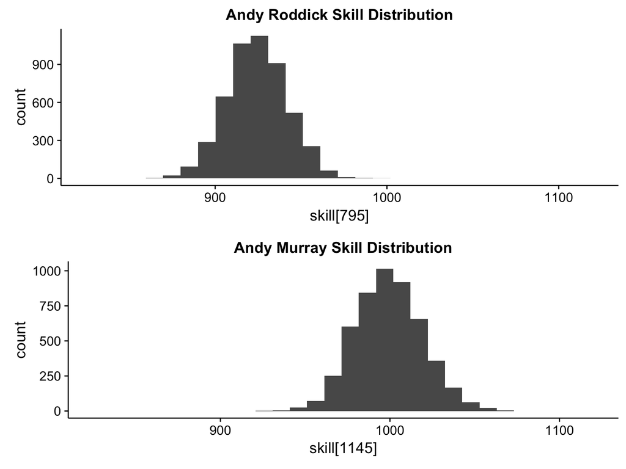

## Posterior winning probability (part 1)

```r
samples <- read_csv("data/samples/model1.csv")

roddick_skill_dist <- df %>% .$`skill[795]`
murray_skill_dist <- df %>% .$`skill[1145]`
consistency <- df %>% .$`consistency`
prob_murray_win_dist <- numeric(1000)

for (i in 1:1000){
    roddick_skill_val <- sample(roddick_skill_dist, 1)
    murray_skill_val <- sample(murray_skill_dist, 1)
    consistency_val <- sample(consistency, 1)

    roddick_perf <- rnorm(500, mean = roddick_skill_val, sd = consistency)
    murray_perf <- rnorm(500, mean = murray_skill_val, sd = consistency)
    perf_diff <- murray_perf - roddick_perf

    win_prob <- sum(perf_diff > 0) / length(perf_diff)
    prob_murray_win_dist[i] <- win_prob
}
```

## Posterior winning probability (part 2)

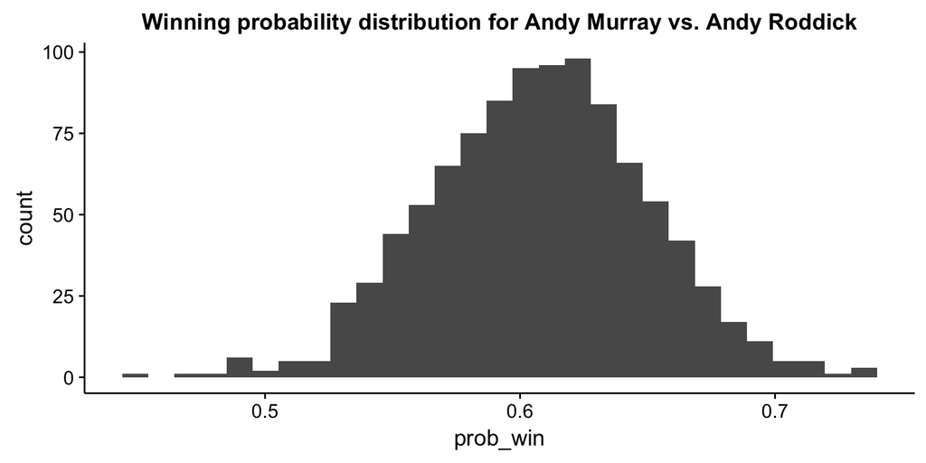

```r
print(mean(prob_murray_win_dist))
```

```
## [1] 0.607514
```

## Model critique & extensions

Critiquing the model

- Split data into train / validation / test split
- Posterior predictive checks

Extending the model

- Consistency distribution for each player
- Skill change over time
- Take other variables into account
  - Court surface (clay, grass, etc.)
  - Point differential
  - …

Betting: Kelly criterion

## Applications

- TrueSkill - Xbox Live
- Ad Placement
- Facebook Prophet - time series forecasting
- Spam detection

## Futher reading

- [Bayesian Methods for Hackers](https://github.com/CamDavidsonPilon/Probabilistic-Programming-and-Bayesian-Methods-for-Hackers)
- [Doing Bayesian Data Analysis](https://sites.google.com/site/doingbayesiandataanalysis/)
- [The Algorithms Behind Probabilistic Programming](http://blog.fastforwardlabs.com/2017/01/30/the-algorithms-behind-probabilistic-programming.html)
- [Bayesian Deep Learing](https://blog.quantopian.com/bayesian-deep-learning/)